# Locating data

In this notebook, we show how to contruct the eCDF of a continuous variable, how to compute quantiles and finally to draw a boxplot.

```python
import numpy as np
import pandas as pd
import matplotlib.pyplot as plt
```

```python
df = pd.read_csv('data/cartelStability.csv')
df
```

|  | rownames | price | cartel | quantity | season | ice |
| --- | --- | --- | --- | --- | --- | --- |
| 0 | 1 | 0.40 | yes | 13632 | Jan 1 - Jan 28 | yes |
| 1 | 2 | 0.40 | yes | 20035 | Jan 1 - Jan 28 | yes |
| 2 | 3 | 0.40 | yes | 16319 | Jan 1 - Jan 28 | yes |
| 3 | 4 | 0.40 | yes | 12603 | Jan 1 - Jan 28 | yes |
| 4 | 5 | 0.40 | yes | 23079 | Jan 29 - Feb 25 | yes |
| ... | ... | ... | ... | ... | ... | ... |
| 323 | 324 | 0.25 | yes | 19686 | Feb 26 - Mar 26 | yes |
| 324 | 325 | 0.25 | yes | 14757 | Mar 27 - Apr 23 | yes |
| 325 | 326 | 0.25 | yes | 16502 | Mar 27 - Apr 23 | yes |
| 326 | 327 | 0.25 | yes | 11490 | Mar 27 - Apr 23 | yes |
| 327 | 328 | 0.25 | yes | 7843 | Mar 27 - Apr 23 | yes |

328 rows × 6 columns

```python
x = np.array(df['quantity'][:])
n= len(x)
x, n
```

```
(array([13632, 20035, 16319, 12603, 23079, 19652, 16211, 22914, 23710,
        23036, 38414, 46906, 58608, 51225, 37339, 20298, 13699, 11944,
        10658,  9756,  9546, 16713, 16389, 23179, 34999, 35267, 20402,
        21020, 16612, 14834, 11149, 16035, 18555, 17413, 19412, 20240,
        11824, 17793, 20157, 18623, 19062, 20840, 18972, 19690, 20206,
        23081, 21209, 13753, 14956, 13295, 16935, 24499, 20078, 24144,
        26157, 22055, 21973, 23794, 23116, 23578, 21568, 17494, 16260,
        26690, 21723, 30625, 36618, 42182, 47432, 43822, 36457, 29093,
        21729, 21265, 18505, 14540, 19366, 55732, 42346, 28960, 30434,
        26139, 31075, 29433, 29136, 31126, 35384, 36701, 37771, 38247,
        39518, 30603, 28383, 24678, 27839, 26767, 24041, 23355, 26491,
        20900, 26410, 26195, 22427, 27535, 25738, 23429, 32745, 37950,
        41466, 49276, 37850, 32893, 24410, 15104, 13819, 22959, 14486,
        15254, 16607, 17475, 12704, 14399, 12023,  9626,  6482, 10520,
        12588, 12468, 10930, 10997,  8618,  4810,  5832,  8536, 11204,
```

[output cut: 23 more lines]

# eCDF

In order to construct the eCDF, we need to sort the data from $-\infty$ to $+\infty$.

```python
x.sort() # the vector x is changed by the method sort
x
```

```
array([ 4810,  5832,  6482,  7528,  7627,  7843,  8536,  8618,  9374,
        9546,  9626,  9756,  9778,  9888,  9978, 10520, 10591, 10658,
       10713, 10737, 10901, 10930, 10997, 11080, 11149, 11204, 11490,
       11508, 11626, 11824, 11906, 11944, 12023, 12292, 12344, 12468,
       12588, 12603, 12704, 12836, 12996, 12996, 13004, 13182, 13295,
       13632, 13699, 13753, 13782, 13819, 14399, 14486, 14492, 14540,
       14622, 14680, 14757, 14761, 14763, 14834, 14852, 14868, 14956,
       15104, 15114, 15181, 15254, 15259, 15480, 15498, 15531, 15576,
       15773, 16035, 16179, 16211, 16260, 16319, 16389, 16502, 16522,
       16595, 16607, 16612, 16685, 16713, 16754, 16935, 16938, 17056,
       17154, 17271, 17413, 17475, 17494, 17686, 17793, 17868, 17914,
       17942, 18121, 18262, 18340, 18461, 18505, 18555, 18623, 18972,
       18972, 18981, 19062, 19128, 19362, 19366, 19412, 19415, 19440,
       19466, 19652, 19686, 19690, 20035, 20078, 20085, 20157, 20206,
       20240, 20298, 20377, 20402, 20716, 20840, 20864, 20881, 20900,
```

[output cut: 22 more lines]

With the following command, we chck whether there are equal values: `np.diff(x)` makes the vector of differences $x_{i+1}-x_i$ and if the minimum of those differences is 0, it means thaht some of the values are equal.

```python
np.min(np.diff(x))
```

```
0
```

Since there are equal values, we proceed as for a discrete variable (cf. preceeding notebook):

```python
unique, freq = np.unique(x, return_counts = True)
cumul_freq = np.cumsum(freq)
cumul_freq = np.insert(cumul_freq, 0, 0)
cumul_freq
```

```
array([  0,   1,   2,   3,   4,   5,   6,   7,   8,   9,  10,  11,  12,
        13,  14,  15,  16,  17,  18,  19,  20,  21,  22,  23,  24,  25,
        26,  27,  28,  29,  30,  31,  32,  33,  34,  35,  36,  37,  38,
        39,  40,  42,  43,  44,  45,  46,  47,  48,  49,  50,  51,  52,
        53,  54,  55,  56,  57,  58,  59,  60,  61,  62,  63,  64,  65,
        66,  67,  68,  69,  70,  71,  72,  73,  74,  75,  76,  77,  78,
        79,  80,  81,  82,  83,  84,  85,  86,  87,  88,  89,  90,  91,
        92,  93,  94,  95,  96,  97,  98,  99, 100, 101, 102, 103, 104,
       105, 106, 107, 109, 110, 111, 112, 113, 114, 115, 116, 117, 118,
       119, 120, 121, 122, 123, 124, 125, 126, 127, 128, 129, 130, 131,
       132, 133, 134, 135, 136, 137, 138, 139, 140, 141, 142, 143, 144,
       145, 146, 147, 148, 149, 150, 151, 152, 153, 154, 155, 156, 157,
       158, 159, 160, 161, 162, 163, 164, 165, 166, 167, 168, 169, 170,
       171, 172, 173, 174, 175, 176, 177, 178, 179, 180, 181, 182, 183,
       184, 185, 186, 187, 188, 189, 190, 191, 192, 193, 194, 195, 196,
       197, 198, 199, 200, 201, 202, 203, 204, 205, 206, 207, 208, 209,
       210, 211, 212, 213, 214, 215, 216, 217, 219, 220, 221, 222, 223,
       224, 225, 226, 227, 228, 229, 230, 231, 232, 233, 234, 235, 236,
       237, 238, 239, 240, 241, 242, 243, 244, 245, 246, 247, 248, 249,
       250, 251, 252, 253, 254, 255, 256, 257, 258, 259, 260, 261, 262,
       263, 264, 265, 266, 267, 268, 269, 270, 271, 272, 273, 274, 275,
       276, 277, 278, 279, 280, 281, 282, 283, 284, 285, 286, 287, 288,
       289, 290, 291, 292, 293, 294, 295, 296, 297, 298, 299, 300, 301,
       302, 303, 304, 305, 306, 307, 308, 309, 310, 311, 312, 313, 314,
       315, 316, 317, 318, 319, 320, 321, 322, 323, 324, 325, 326, 327,
       328])
```

```python
F = cumul_freq/n
len(F), len(unique)
```

```
(326, 325)
```

```python
a, b = 0., 80000
t = np.insert(unique, 0, a)
t = np.append(t, b)
t, len(t)
```

```
(array([    0,  4810,  5832,  6482,  7528,  7627,  7843,  8536,  8618,
         9374,  9546,  9626,  9756,  9778,  9888,  9978, 10520, 10591,
        10658, 10713, 10737, 10901, 10930, 10997, 11080, 11149, 11204,
        11490, 11508, 11626, 11824, 11906, 11944, 12023, 12292, 12344,
        12468, 12588, 12603, 12704, 12836, 12996, 13004, 13182, 13295,
        13632, 13699, 13753, 13782, 13819, 14399, 14486, 14492, 14540,
        14622, 14680, 14757, 14761, 14763, 14834, 14852, 14868, 14956,
        15104, 15114, 15181, 15254, 15259, 15480, 15498, 15531, 15576,
        15773, 16035, 16179, 16211, 16260, 16319, 16389, 16502, 16522,
        16595, 16607, 16612, 16685, 16713, 16754, 16935, 16938, 17056,
        17154, 17271, 17413, 17475, 17494, 17686, 17793, 17868, 17914,
        17942, 18121, 18262, 18340, 18461, 18505, 18555, 18623, 18972,
        18981, 19062, 19128, 19362, 19366, 19412, 19415, 19440, 19466,
        19652, 19686, 19690, 20035, 20078, 20085, 20157, 20206, 20240,
        20298, 20377, 20402, 20716, 20840, 20864, 20881, 20900, 20970,
```

[output cut: 23 more lines]

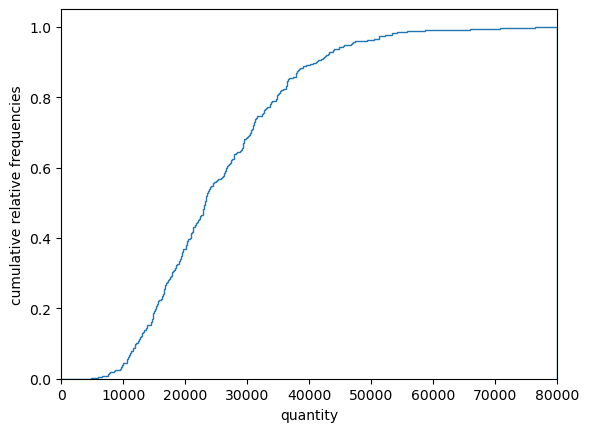

```python
plt.stairs(F,t)
plt.xlim(a,b)
plt.ylabel('cumulative relative frequencies')
plt.xlabel('quantity')
plt.show()
```

## quantiles

We can define the quatiles vectorially. Here we define the quantiles $q_0=\min(x)$, $q_{0.25} = Q1$, $q_{0.5} = M$, $q_{0.75} = Q3$ and $q_1 =\max(x)$.

```python
alpha=[0, 0.25,0.5,0.75, 1]
q = np.quantile(x,alpha, method = 'higher') # we discussed already the choice of the parameter higher during the lecture
q
```

```
array([ 4810, 16607, 23116, 32428, 76407])
```

We can read graphically the quartiles on the eCDF:

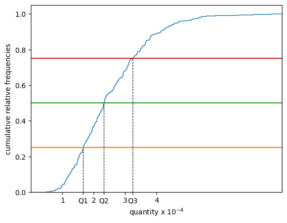

```python
plt.stairs(F,t)
plt.xlim(a,b)
for i in range(1,4):
    plt.plot([a,b],[alpha[i],alpha[i]])
    plt.plot([q[i],q[i]],[0.,alpha[i]], 'k--', linewidth = 0.8)
plt.ylabel('cumulative relative frequencies')
plt.xlabel('quantity x $10^{-4}$')
plt.xticks([10000,q[1], 20000, q[2],30000, q[3], 40000], [1,'Q1', 2,'Q2', 3,'Q3', 4])
plt.show()
```

## eCDF and histogram

The quantiles may be also read on the histogram since it represents the distributio of the values of the variable. On the below graph, the quantiles cut the total distribution mass into 4 quarters.

```python
tab = pd.read_csv('cartelStability/table_quantity.csv', index_col = 0)
tab
```

|  | lo | hi | frequencies | relative frequencies | cumulative relative frequencies |
| --- | --- | --- | --- | --- | --- |
| 0 | 0.0 | 8000.0 | 6.0 | 0.018293 | 0.018293 |
| 1 | 8000.0 | 12000.0 | 26.0 | 0.079268 | 0.097561 |
| 2 | 12000.0 | 16000.0 | 41.0 | 0.125000 | 0.222561 |
| 3 | 16000.0 | 20000.0 | 48.0 | 0.146341 | 0.368902 |
| 4 | 20000.0 | 24000.0 | 57.0 | 0.173780 | 0.542683 |
| 5 | 24000.0 | 28000.0 | 31.0 | 0.094512 | 0.637195 |
| 6 | 28000.0 | 32000.0 | 36.0 | 0.109756 | 0.746951 |
| 7 | 32000.0 | 36000.0 | 25.0 | 0.076220 | 0.823171 |
| 8 | 36000.0 | 40000.0 | 22.0 | 0.067073 | 0.890244 |
| 9 | 40000.0 | 44000.0 | 15.0 | 0.045732 | 0.935976 |
| 10 | 44000.0 | 52000.0 | 12.0 | 0.036585 | 0.972561 |
| 11 | 52000.0 | 80000.0 | 9.0 | 0.027439 | 1.000000 |

```python
# re-buikding the histogram from the frequency table
fi = np.array(tab['relative frequencies'][:])
lo = np.array(tab['lo'])
hi = np.array(tab['hi'])
length = hi-lo
height = fi/length
bin_edges = np.append(lo,hi[-1])
```

```python
# the maw of the histogram is required for drawing purposes only
m = max(height)
```

In order to illustrate our statement, we draw both the eCDF and the histogram on the same graphic, one above the other. This may be done by the `subplot` command: the two first arguments give the size of the grid (rows and columns, here 2 raws and 1 column) and the last argument give the number of the current graph on the grid (from 1 to the total number of graphs, raw by raw, top to bottom):

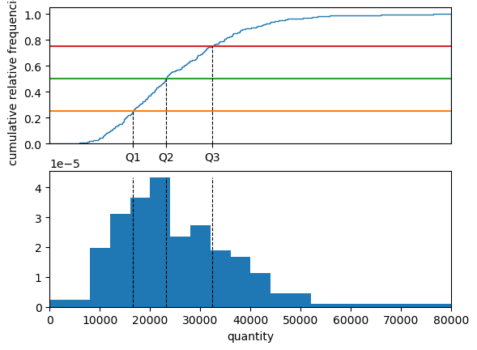

```python
plt.subplot(2,1,1)
plt.stairs(F,t)
plt.xlim(a,b)
for i in range(1,4):
    plt.plot([a,b],[alpha[i],alpha[i]])
    plt.plot([q[i],q[i]],[0.,alpha[i]], 'k--', linewidth = 0.8)
plt.ylabel('cumulative relative frequencies')
plt.xticks(q[1:4], ['Q1','Q2','Q3',])
plt.subplot(2,1,2)
plt.xlim(a,b)
plt.hist(bin_edges[:-1], bins = bin_edges, weights = height)
for i in range(1,4):
    plt.plot([q[i],q[i]],[0.,m], 'k--', linewidth = 0.8)
plt.xlabel('quantity')
plt.show()
```

# Boxplot

The `plt.boxplot` command does the job with no pre-treatment.

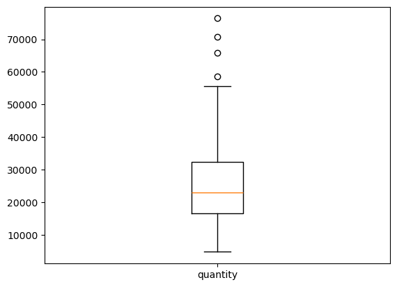

```python
plt.boxplot(x)
plt.xticks([1],['quantity'])
plt.show()
```